# Logistic Regression Hyperparameter Tuning - Reweighing

#### This notebook complements the Modeling notebook, and is dedicated to the Logistic Regression hyperparameter tuning. The parameters of the best performing model generated by this notebook will serve as a the foundation for the final model configuration in the Modeling notebook.

### Import Libraries

```python
import warnings
warnings.filterwarnings('ignore')

import pandas as pd
import numpy as np
import matplotlib.pyplot as plt
import plotly.express as px
import seaborn as sns
import pyarrow.parquet as pq
import pyarrow as pa
```

```python
from sklearn.linear_model import LogisticRegression
from sklearn.model_selection import GridSearchCV, KFold
from sklearn.metrics import roc_auc_score
from sklearn.preprocessing import StandardScaler
from sklearn.pipeline import Pipeline
from sklearn.model_selection import ParameterGrid
from sklearn.compose import ColumnTransformer
from sklearn.metrics import confusion_matrix, accuracy_score
from sklearn.metrics import make_scorer
import statsmodels.api as sm
```

**Read train and test datasets with all features**

```python
X_train = pd.read_parquet('./data_treated/X_train.parquet')
y_train = pd.read_parquet('./data_treated/y_train.parquet')

X_test = pd.read_parquet('./data_treated/X_test.parquet')
y_test = pd.read_parquet('./data_treated/y_test.parquet')
```

```python
np.mean(y_train)
```

```
isClick    0.049943
dtype: float64
```

```python
np.mean(y_test)
```

```
isClick    0.049563
dtype: float64
```

### Logistic Regression Hyperparameter Tuning

In this section, our objective is to determine the optimal regularization parameter (C) that achieves a balance between model performance on the training data and generalizability. Employing a grid search approach, we evaluate the model's effectiveness across various values of C, considering different settings for the maximum number of iterations.

Our assessment of hyperparameter sets revolves around two key performance metrics: accuracy and the area under the receiver operating characteristic curve (AUC). These metrics provide a comprehensive understanding of the model's ability to accurately classify observations in both the majority and minority classes.

Upon completing the grid search, our primary goal is to pinpoint the regularization parameter that yields the highest accuracy and AUC on the validation sets within the k-fold cross-validation. This optimal parameter will then form the foundation for the final model configuration.

```python
numerical_cols = ['impressPosition', 'impressTime_dhour', 'prior_user_probClick', 'prior_user_probLike',
                  'prior_user_probShare', 'prior_user_probComment', 'prior_user_probSwipe', 'prior_user_probCheckCreator',
                  'prior_user_avgViewDuration', 'prior_card_probClick', 'prior_card_probLike', 'user_age', 'user_tenure',
                  'user_is_creator', 'publishTime', 'creator_tenure', 'creator_level', 'creator_logFollows',
                  'creator_logFolloweds', 'past_pref_artist_probClick', 'past_pref_song_probClick',
                  'past_pref_creator_probClick']
```

```python
# Function to evaluate the model using k-fold cross-validation
def evaluate_model(X_train, y_train, n_folds, param_grid):
    scoring_metric = {'AUC': 'roc_auc', 'Accuracy': 'accuracy'}
    scores, models = list(), list()

    # Define preprocessor for normalization
    preprocessor = ColumnTransformer(
        transformers=[
            ('num', StandardScaler(), numerical_cols)
        ],
        remainder='passthrough'
    )

    # Create a pipeline with a preprocessor and Logistic Regression
    pipeline = Pipeline([
        ('preprocessor', preprocessor),
        ('logistic_regression', LogisticRegression(class_weight='balanced', n_jobs=-1))
    ])

    # Initialize GridSearchCV with the pipeline and parameter grid
    searcher = GridSearchCV(
        pipeline,
        param_grid=param_grid,
        cv=n_folds,
        scoring=scoring_metric,
        refit='AUC',  # Refit based on AUC
        verbose=2
    )

    # Fit the GridSearchCV on the data
    searcher.fit(X_train, y_train)

    # Print mean and std deviation of scores
    print("\n\nMean AUC: {:.3f}, Mean Accuracy: {:.3f}".format(searcher.cv_results_['mean_test_AUC'][searcher.best_index_],
                                                           searcher.cv_results_['mean_test_Accuracy'][searcher.best_index_]))
    print("Std Dev AUC: {:.3f}, Std Dev Accuracy: {:.3f}".format(searcher.cv_results_['std_test_AUC'][searcher.best_index_],
                                                                 searcher.cv_results_['std_test_Accuracy'][searcher.best_index_]))

    # Append scores
    scores.append(searcher.cv_results_['mean_test_AUC'][searcher.best_index_])
    models.append(searcher.best_estimator_)

    return scores, models, searcher

# Example hyperparameter grid for grid search
param_grid_lr = {
    'logistic_regression__C': np.logspace(-2, 1, 15),
    'logistic_regression__max_iter': [100, 200]
}

# Perform grid search
current_scores_lr, models, searcher = evaluate_model(X_train, y_train, n_folds=5, param_grid=param_grid_lr)
```

```
Fitting 5 folds for each of 30 candidates, totalling 150 fits
[CV] END logistic_regression__C=0.01, logistic_regression__max_iter=100; total time= 1.4min
[CV] END logistic_regression__C=0.01, logistic_regression__max_iter=100; total time= 1.1min
[CV] END logistic_regression__C=0.01, logistic_regression__max_iter=100; total time= 1.0min
[CV] END logistic_regression__C=0.01, logistic_regression__max_iter=100; total time= 1.1min
[CV] END logistic_regression__C=0.01, logistic_regression__max_iter=100; total time= 1.0min
[CV] END logistic_regression__C=0.01, logistic_regression__max_iter=200; total time= 1.9min
[CV] END logistic_regression__C=0.01, logistic_regression__max_iter=200; total time= 1.8min
[CV] END logistic_regression__C=0.01, logistic_regression__max_iter=200; total time= 1.8min
[CV] END logistic_regression__C=0.01, logistic_regression__max_iter=200; total time= 1.9min
[CV] END logistic_regression__C=0.01, logistic_regression__max_iter=200; total time= 1.8min
[CV] END logistic_regression__C=0.016378937069540637, logistic_regression__max_iter=100; total time= 1.0min
[CV] END logistic_regression__C=0.016378937069540637, logistic_regression__max_iter=100; total time=  59.9s
[CV] END logistic_regression__C=0.016378937069540637, logistic_regression__max_iter=100; total time= 1.0min
[CV] END logistic_regression__C=0.016378937069540637, logistic_regression__max_iter=100; total time= 1.0min
[CV] END logistic_regression__C=0.016378937069540637, logistic_regression__max_iter=100; total time= 1.0min
[CV] END logistic_regression__C=0.016378937069540637, logistic_regression__max_iter=200; total time= 1.9min
[CV] END logistic_regression__C=0.016378937069540637, logistic_regression__max_iter=200; total time= 1.7min
[CV] END logistic_regression__C=0.016378937069540637, logistic_regression__max_iter=200; total time= 1.8min
[CV] END logistic_regression__C=0.016378937069540637, logistic_regression__max_iter=200; total time= 1.7min
[CV] END logistic_regression__C=0.016378937069540637, logistic_regression__max_iter=200; total time= 1.8min
[CV] END logistic_regression__C=0.02682695795279726, logistic_regression__max_iter=100; total time= 1.0min
[CV] END logistic_regression__C=0.02682695795279726, logistic_regression__max_iter=100; total time= 1.0min
[CV] END logistic_regression__C=0.02682695795279726, logistic_regression__max_iter=100; total time= 1.0min
[CV] END logistic_regression__C=0.02682695795279726, logistic_regression__max_iter=100; total time= 1.0min
[CV] END logistic_regression__C=0.02682695795279726, logistic_regression__max_iter=100; total time=  59.9s
[CV] END logistic_regression__C=0.02682695795279726, logistic_regression__max_iter=200; total time= 1.8min
[CV] END logistic_regression__C=0.02682695795279726, logistic_regression__max_iter=200; total time= 1.9min
[CV] END logistic_regression__C=0.02682695795279726, logistic_regression__max_iter=200; total time= 1.8min
[CV] END logistic_regression__C=0.02682695795279726, logistic_regression__max_iter=200; total time= 1.9min
[CV] END logistic_regression__C=0.02682695795279726, logistic_regression__max_iter=200; total time= 1.8min
[CV] END logistic_regression__C=0.043939705607607904, logistic_regression__max_iter=100; total time= 1.0min
[CV] END logistic_regression__C=0.043939705607607904, logistic_regression__max_iter=100; total time= 1.0min
[CV] END logistic_regression__C=0.043939705607607904, logistic_regression__max_iter=100; total time= 1.0min
[CV] END logistic_regression__C=0.043939705607607904, logistic_regression__max_iter=100; total time= 1.0min
[CV] END logistic_regression__C=0.043939705607607904, logistic_regression__max_iter=100; total time= 1.0min
[CV] END logistic_regression__C=0.043939705607607904, logistic_regression__max_iter=200; total time= 2.9min
[CV] END logistic_regression__C=0.043939705607607904, logistic_regression__max_iter=200; total time= 2.9min
[CV] END logistic_regression__C=0.043939705607607904, logistic_regression__max_iter=200; total time= 2.9min
[CV] END logistic_regression__C=0.043939705607607904, logistic_regression__max_iter=200; total time= 2.9min
```

[output cut: 100 more lines]

```
[CV] END logistic_regression__C=6.105402296585327, logistic_regression__max_iter=200; total time= 1.8min
[CV] END logistic_regression__C=10.0, logistic_regression__max_iter=100; total time=  59.6s
[CV] END logistic_regression__C=10.0, logistic_regression__max_iter=100; total time= 1.0min
[CV] END logistic_regression__C=10.0, logistic_regression__max_iter=100; total time= 1.0min
[CV] END logistic_regression__C=10.0, logistic_regression__max_iter=100; total time= 1.1min
[CV] END logistic_regression__C=10.0, logistic_regression__max_iter=100; total time= 1.0min
[CV] END logistic_regression__C=10.0, logistic_regression__max_iter=200; total time= 1.8min
[CV] END logistic_regression__C=10.0, logistic_regression__max_iter=200; total time= 1.9min
[CV] END logistic_regression__C=10.0, logistic_regression__max_iter=200; total time= 1.8min
[CV] END logistic_regression__C=10.0, logistic_regression__max_iter=200; total time= 1.8min
[CV] END logistic_regression__C=10.0, logistic_regression__max_iter=200; total time= 1.8min


Mean AUC: 0.647, Mean Accuracy: 0.655
Std Dev AUC: 0.001, Std Dev Accuracy: 0.001
```

```python
print("Best Hyperparameters", searcher.best_params_)
best_params_LR = searcher.best_params_
```

```
Best Hyperparameters {'logistic_regression__C': 0.02682695795279726, 'logistic_regression__max_iter': 100}
```

```python
# Initialize preprocessor for normalization
preprocessor = ColumnTransformer(
    transformers=[
        ('num', StandardScaler(), numerical_cols)
    ],
    remainder='passthrough'
)

# Create a pipeline with a preprocessor and Logistic Regression
final_pipeline = Pipeline([
    ('preprocessor', preprocessor),
    ('logistic_regression', LogisticRegression(C= best_params_LR['logistic_regression__C'], class_weight='balanced'))
])

# Fit the final model on the full training data
final_pipeline.fit(X_train, y_train)

# Print feature importance
feature_importance = final_pipeline.named_steps['logistic_regression'].coef_[0]
feature_names = X_train.columns
# Extract X_train with the preprocessor
X_train_processed = final_pipeline.named_steps['preprocessor'].transform(X_train)

# Fit logistic regression with statsmodels for p-values
logit_model = sm.Logit(y_train, sm.add_constant(X_train_processed))
result = logit_model.fit()
```

```
Optimization terminated successfully.
         Current function value: 0.191964
         Iterations 9
```

```
Accuracy Score on Full Training Data: 65.42%
```

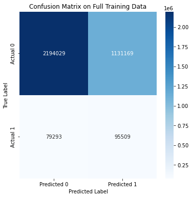

```python
# Predict on the full training data
y_pred_train = final_pipeline.predict(X_train)


# Print accuracy score on the full training data
accuracy_train = accuracy_score(y_train, y_pred_train)
print(f"\nAccuracy Score on Full Training Data: {accuracy_train * 100:.2f}%")


# Print confusion matrix
cm = confusion_matrix(y_train, y_pred_train)
plt.figure(figsize=(6, 6))
sns.heatmap(cm, annot=True, fmt="d", cmap="Blues", xticklabels=['Predicted 0', 'Predicted 1'],
            yticklabels=['Actual 0', 'Actual 1'])
plt.xlabel('Predicted Label')
plt.ylabel('True Label')
plt.title('Confusion Matrix on Full Training Data')
plt.show()
```

```
Accuracy Score on Test Data: 65.38%
```

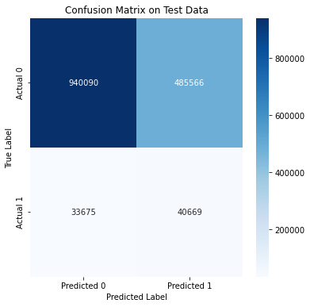

```python
# Predict on the test data
y_pred_test = final_pipeline.predict(X_test)


# Print accuracy score on test data
accuracy_test = accuracy_score(y_test, y_pred_test)
print(f"\nAccuracy Score on Test Data: {accuracy_test * 100:.2f}%")


# Print confusion matrix
cm = confusion_matrix(y_test, y_pred_test)
plt.figure(figsize=(6, 6))
sns.heatmap(cm, annot=True, fmt="d", cmap="Blues", xticklabels=['Predicted 0', 'Predicted 1'],
            yticklabels=['Actual 0', 'Actual 1'])
plt.xlabel('Predicted Label')
plt.ylabel('True Label')
plt.title('Confusion Matrix on Test Data')
plt.show()
```

**Conclusion**: Upon comparing the model's performance on the training and test datasets, we observe a robust and predictive model, as evidenced by nearly identical accuracy scores on both datasets. The model exhibits a commendable ability to distinguish between users who click on the recommended card and those who do not. This is evident in the recall (true positive) rate of 55% and the true negative rate of 66%, striking a good balance between sensitivity and specificity, specially considering that the dataset is quite unbalanced.

**Save the best-performance parameters**

```python
import pickle

with open('best_params_LR_reweighing.pkl', 'wb') as file:
    pickle.dump(best_params_LR, file)
```